# Bayesian Urban Air Quality Forecasting & Health Risk Analysis

## 3.2 Missing Data Analysis

```r
missing_pct <- pollution %>%
  group_by(site_code) %>%
  summarise(
    n_total   = n(),
    n_missing = sum(is.na(pm2.5)),
    pct_miss  = round(n_missing / n_total * 100, 2)
  )

missing_pct %>%
  kable(caption = "Missing PM2.5 data by site",
        col.names = c("Site", "Total days", "Missing days", "% Missing")) %>%
  kable_styling(bootstrap_options = c("striped", "condensed"), full_width = FALSE)
```

Missing PM2.5 data by site

| Site | Total days | Missing days | % Missing |
| --- | --- | --- | --- |
| BT1 | 2191 | 0 | 0 |
| HRL | 2191 | 0 | 0 |
| KC1 | 2191 | 0 | 0 |
| MY1 | 2191 | 0 | 0 |

## 3.3 Seasonal Patterns

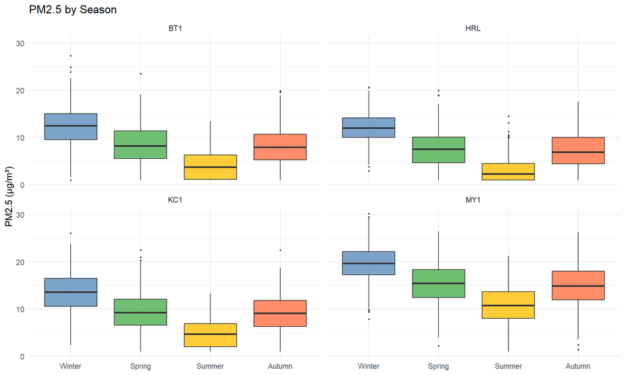

PM2.5 by season across monitoring sites.

```r
pollution %>%
  filter(!is.na(pm2.5)) %>%
  mutate(season = factor(season, levels = c("Winter","Spring","Summer","Autumn"))) %>%
  ggplot(aes(x = season, y = pm2.5, fill = season)) +
  geom_boxplot(outlier.size = 0.5, alpha = 0.8) +
  facet_wrap(~site_code) +
  scale_fill_manual(values = c("Winter"="#5B8DBE","Spring"="#4CAF50",
                                "Summer"="#FFC107","Autumn"="#FF7043")) +
  labs(title = "PM2.5 by Season", x = NULL, y = "PM2.5 (µg/m³)") +
  theme_minimal(base_size = 11) + theme(legend.position = "none")
```

Winter PM2.5 is consistently higher due to:

1. **Residential heating** — wood and solid fuel burning
2. **Atmospheric inversions** — cold air traps pollution near the surface
3. **Reduced photochemical dispersion** — less UV light in winter

## 3.4 WHO Guideline Exceedances

```r
who_exceedances <- pollution %>%
  filter(!is.na(pm2.5)) %>%
  group_by(site_code, year) %>%
  summarise(
    annual_mean = round(mean(pm2.5), 1),
    days_over   = sum(pm2.5 > 15),
    pct_over    = round(mean(pm2.5 > 15) * 100, 1),
    .groups = "drop"
  )

who_exceedances %>%
  pivot_wider(names_from = site_code, values_from = c(annual_mean, pct_over)) %>%
  kable(caption = "Annual mean PM2.5 and % days exceeding WHO guideline (15 µg/m³)") %>%
  kable_styling(bootstrap_options = c("striped", "hover"), full_width = FALSE)
```

Annual mean PM2.5 and % days exceeding WHO guideline (15 µg/m³)

| year | days_over | annual_mean_BT1 | annual_mean_HRL | annual_mean_KC1 | annual_mean_MY1 | pct_over_BT1 | pct_over_HRL | pct_over_KC1 | pct_over_MY1 |
| --- | --- | --- | --- | --- | --- | --- | --- | --- | --- |
| 2018 | 66 | 10.3 | NA | NA | NA | 18.1 | NA | NA | NA |
| 2019 | 46 | 9.9 | NA | NA | NA | 12.6 | NA | NA | NA |
| 2020 | 51 | 9.6 | NA | NA | NA | 13.9 | NA | NA | NA |
| 2021 | 28 | 8.5 | NA | NA | NA | 7.7 | NA | NA | NA |
| 2022 | 2 | 5.9 | NA | NA | NA | 0.5 | NA | NA | NA |
| 2023 | 2 | 5.3 | NA | NA | NA | 0.5 | NA | NA | NA |
| 2018 | 31 | NA | 8.5 | NA | NA | NA | 8.5 | NA | NA |
| 2019 | 21 | NA | 8.0 | NA | NA | NA | 5.8 | NA | NA |
| 2020 | 24 | NA | 7.7 | NA | NA | NA | 6.6 | NA | NA |
| 2021 | 17 | NA | 7.4 | NA | NA | NA | 4.7 | NA | NA |
| 2022 | 12 | NA | 6.6 | NA | NA | NA | 3.3 | NA | NA |
| 2023 | 7 | NA | 6.3 | NA | NA | NA | 1.9 | NA | NA |
| 2018 | 76 | NA | NA | 11.3 | NA | NA | NA | 20.8 | NA |
| 2019 | 79 | NA | NA | 11.0 | NA | NA | NA | 21.6 | NA |
| 2020 | 79 | NA | NA | 10.5 | NA | NA | NA | 21.6 | NA |
| 2021 | 42 | NA | NA | 9.3 | NA | NA | NA | 11.5 | NA |
| 2022 | 4 | NA | NA | 6.7 | NA | NA | NA | 1.1 | NA |
| 2023 | 9 | NA | NA | 6.3 | NA | NA | NA | 2.5 | NA |
| 2018 | 258 | NA | NA | NA | 17.5 | NA | NA | NA | 70.7 |
| 2019 | 246 | NA | NA | NA | 17.1 | NA | NA | NA | 67.4 |
| 2020 | 213 | NA | NA | NA | 16.3 | NA | NA | NA | 58.2 |
| 2021 | 195 | NA | NA | NA | 15.3 | NA | NA | NA | 53.4 |
| 2022 | 99 | NA | NA | NA | 12.4 | NA | NA | NA | 27.1 |
| 2023 | 100 | NA | NA | NA | 11.9 | NA | NA | NA | 27.4 |

# 4 Generalised Regression Models

```r
glm_results <- readRDS("../data/glm_results.rds")
model_data  <- glm_results$model_data
```

## 4.1 Model Specification

We model daily respiratory admissions $Y_t$ as a function of pollution exposure:

$$Y_t \sim \text{NegBin}(\mu_t,
\theta)$$

$$\log(\mu_t) = \beta_0 + \beta_1 \cdot
\text{PM2.5}_{t} + \beta_2 \cdot \text{PM2.5}_{t-1} + \beta_3 \cdot
\text{PM2.5}_{t-2} + \beta_4 \cdot \text{PM2.5}_{t-3} + \gamma \cdot
\text{Season}_t + \delta \cdot \text{Weekday}_t$$

The **Negative Binomial** family is chosen over Poisson because count health data is typically **overdispersed** (variance > mean). We test this formally:

```r
m1 <- glm_results$m1_poisson
dispersion_ratio <- m1$deviance / m1$df.residual
cat("Dispersion ratio (Residual deviance / df):", round(dispersion_ratio, 3))
```

```
## Dispersion ratio (Residual deviance / df): 2.508
```

```r
cat("\nRatio > 1.5 indicates overdispersion requiring Negative Binomial")
```

```
##
## Ratio > 1.5 indicates overdispersion requiring Negative Binomial
```

## 4.2 Model Comparison

```r
glm_results$model_comparison %>%
  kable(caption = "GLM Model Comparison — lower AIC = better fit",
        digits = 1) %>%
  kable_styling(bootstrap_options = c("striped", "hover"), full_width = FALSE) %>%
  row_spec(1, bold = TRUE, background = "#e8f4f8")  # highlight best model
```

GLM Model Comparison — lower AIC = better fit

| Model | AIC | Deviance | df_residual | delta_AIC |
| --- | --- | --- | --- | --- |
| Negative Binomial | 13698.6 | 2290.3 | 2168 | 0.0 |
| NB + lag effects | 13699.2 | 2290.5 | 2165 | 0.6 |
| Poisson (simple) | 14999.1 | 5438.2 | 2168 | 1300.5 |

## 4.3 Rate Ratios

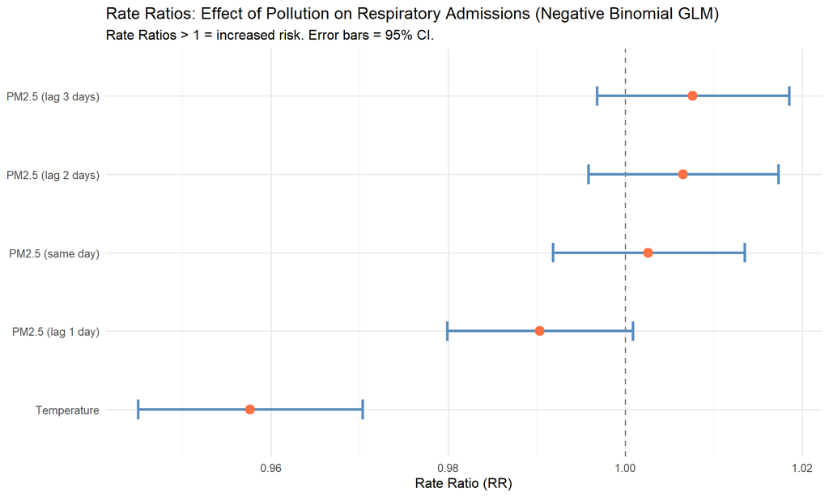

Forest plot of Rate Ratios for pollution effects on respiratory admissions.

```r
glm_results$coefs %>%
  ggplot(aes(x = rr, y = reorder(term_label, rr))) +
  geom_vline(xintercept = 1, colour = "gray50", linetype = "dashed") +
  geom_errorbarh(aes(xmin = rr_low, xmax = rr_high), height = 0.25,
                 colour = "#5B8DBE", linewidth = 1.2) +
  geom_point(size = 3.5, colour = "#FF7043") +
  labs(title = "Rate Ratios: Effect of Pollution on Respiratory Admissions (Negative Binomial GLM)",
       subtitle = "Rate Ratios > 1 = increased risk. Error bars = 95% CI.",
       x = "Rate Ratio (RR)", y = NULL) +
  theme_minimal(base_size = 12)
```